# Analysis of results of the Bayesian delimitation of species with `bpp`

J. Ignacio Lucas Lledó

2026-05-05

# Reading the results

```r
source('mcmc.R')
source('plotModel.R')

one1.t <- read.table('../2025-11-25/onesp/out1.mcmc.txt', header = TRUE)
one2.t <- read.table('../2025-11-25/onesp/out2.mcmc.txt', header = TRUE)
one1.g <- read.table('../2025-11-25/garnatxa/onesp/out1.mcmc.txt', header = TRUE)
one2.g <- read.table('../2025-11-25/garnatxa/onesp/out2.mcmc.txt', header = TRUE)
two1.t <- read.table('../2025-11-25/twosp/out1.mcmc.txt', header = TRUE)
two2.t <- read.table('../2025-11-25/twosp/out2.mcmc.txt', header = TRUE)
mig0.t <- read.table('../2025-11-25/twoMig/out0.mcmc.txt', header = TRUE)
mig1.t <- read.table('../2025-11-25/twoMig/out1.mcmc.txt', header = TRUE)
mig2.t <- read.table('../2025-11-25/twoMig/out2.mcmc.txt', header = TRUE)
mig0.g <- read.table('../2025-11-25/garnatxa/twoMig/out0.mcmc.txt', header = TRUE)
mig1.g <- read.table('../2025-11-25/garnatxa/twoMig/out1.mcmc.txt', header = TRUE)
mig2.g <- read.table('../2025-11-25/garnatxa/twoMig/out2.mcmc.txt', header = TRUE)
```

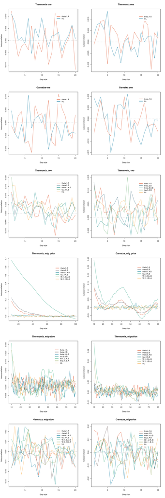

```r
par(mfrow = c(6, 2))
autocorPlot(one1.t, main = 'Thermomix one')
autocorPlot(one2.t, main = 'Thermomix one')
autocorPlot(one1.g, main = 'Garnatxa one')
autocorPlot(one2.g, main = 'Garnatxa one')
autocorPlot(two1.t, main = 'Thermomix, two')
autocorPlot(two2.t, main = 'Thermomix, two')
autocorPlot(mig0.t, main = 'Thermomix, mig. prior', step = 10:100)
autocorPlot(mig0.g, main = 'Garnatxa, mig. prior', step = 10:80)
autocorPlot(mig1.t, main = 'Thermomix, migration', step = 10:80)
autocorPlot(mig2.t, main = 'Thermomix, migration', step = 10:80)
autocorPlot(mig1.g, main = 'Garnatxa, migration')
autocorPlot(mig2.g, main = 'Garnatxa, migration')
```

Below, I subsample some of the chains, in order to reduce the autocorrelation. I don’t know why the chains exploring the prior show oscillating autocorrelation for some parameters.

```r
one1.t <- one1.t[seq(from = 1, to = nrow(one1.t), by = 5),]
one2.t <- one2.t[seq(from = 1, to = nrow(one2.t), by = 10),]
two1.t <- two1.t[seq(from = 1, to = nrow(two1.t), by = 14),]
two2.t <- two2.t[seq(from = 1, to = nrow(two2.t), by = 10),]
mig0.t <- mig0.t[seq(from = 1, to = nrow(mig0.t), by = 90),]
mig0.g <- mig0.g[seq(from = 1, to = nrow(mig0.g), by = 55),]
mig1.t <- mig1.t[seq(from = 1, to = nrow(mig1.t), by = 20),]
mig2.t <- mig2.t[seq(from = 1, to = nrow(mig2.t), by = 20),]
```

# Checking convergence and merging chains

I don’t show it, to save space, but I did check for tendencies and I confirm that in all chains the burn-in was enough and no tendencies were observed.

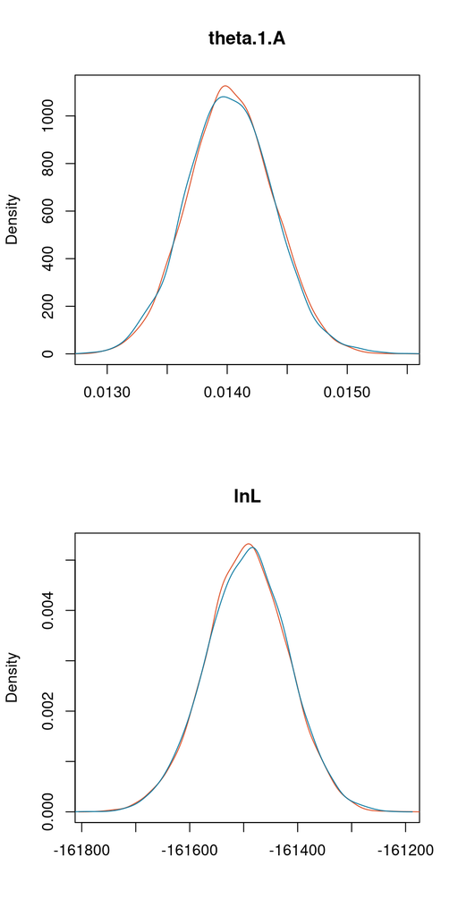

```r
convergencePlot(one1.t, one2.t)
```

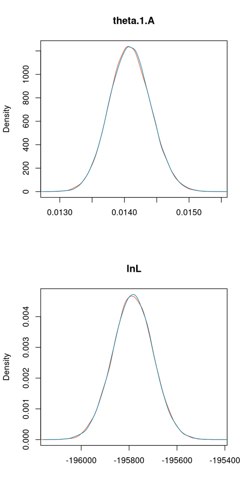

```r
convergencePlot(one1.g, one2.g)
```

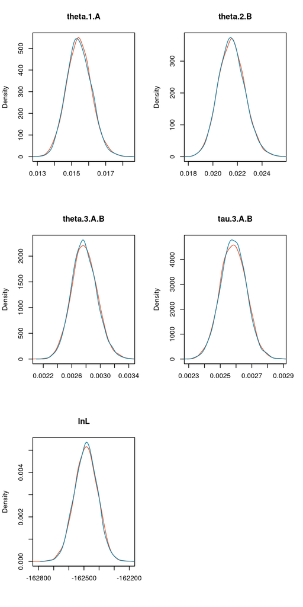

```r
convergencePlot(two1.t, two2.t)
```

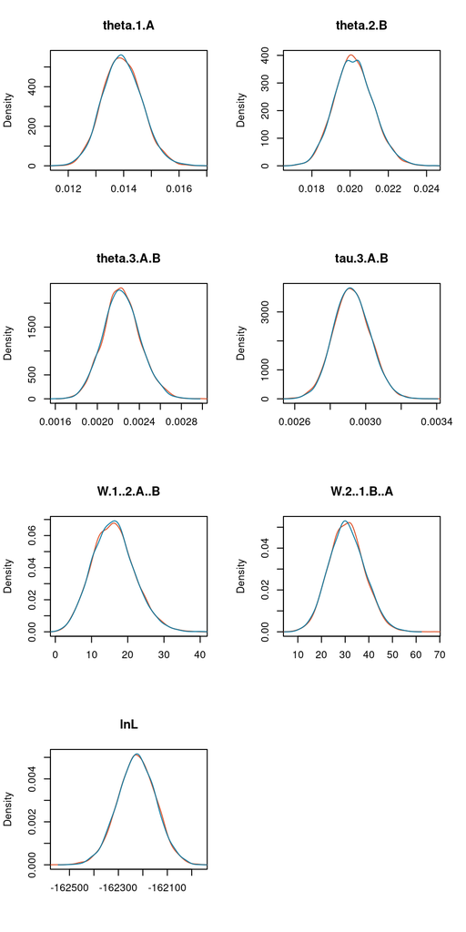

```r
convergencePlot(mig1.t, mig2.t)
```

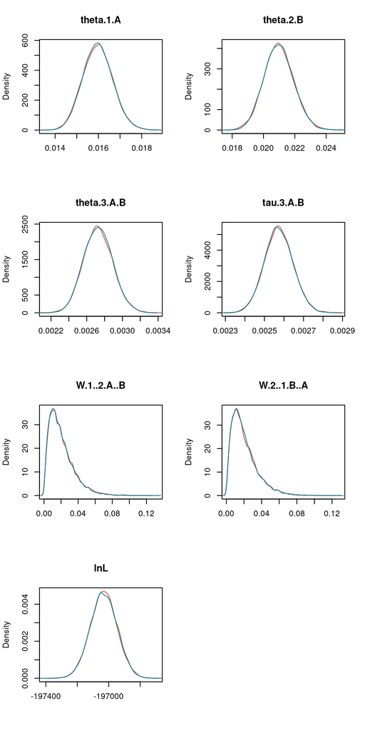

```r
convergencePlot(mig1.g, mig2.g)
```

Convergence is perfect in all cases. Thus, we can consolidate the pairs of runs.

```r
one.t <- rbind(one1.t, one2.t)
one.g <- rbind(one1.g, one2.g)
two.t <- rbind(two1.t, two2.t)
mig.t <- rbind(mig1.t, mig2.t)
mig.g <- rbind(mig1.g, mig2.g)
rm(one1.t, one2.t, one1.g, one2.g, two1.t, two2.t, mig1.t, mig2.t, mig1.g, mig2.g)
```

# Comparison of results produced in Garnatxa and in Thermomix

During the process of running `bpp`, it was necessary to use Garnatxa. For consistency, both the one species model and the model with two species with migration were run in Garnatxa, although they had been run in Thermomix as well. In Garnatxa we took the chance to improve the priors. We had learned that `bpp` defaults to a Gamma distributions unless told otherwise.

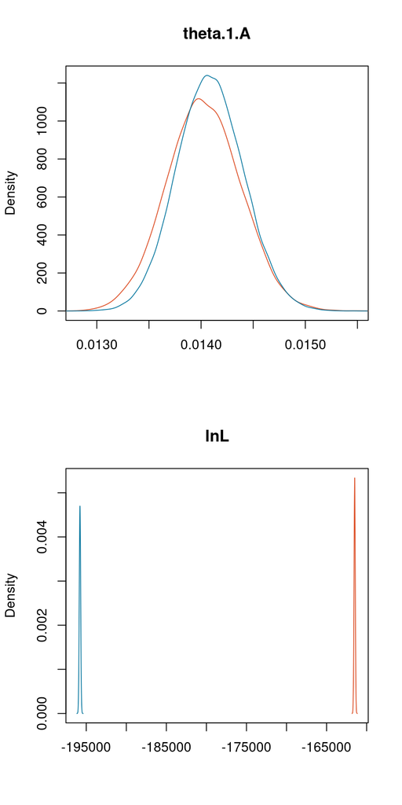

```r
convergencePlot(one.t, one.g)
```

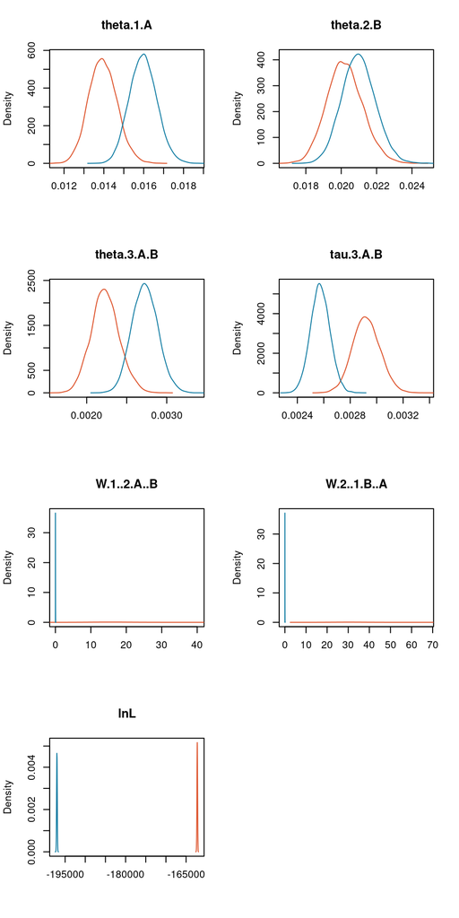

```r
convergencePlot(mig.t, mig.g)
```

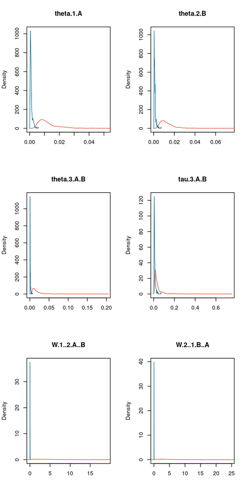

```r
convergencePlot(mig0.t, mig0.g)
```

In all plots above, the red color shows results in Thermomix and blue, in Garnatxa.

When originally running `bpp` in Thermomix, I set up the priors (red line in last set of plots above) to reflect the believe of populations possibly being large, the divergence not very large, and migration potentially intense. Then, first results had me concerned that the priors could have been too informative. An overlap between the prior and the posterior suggests lack of power in the data to update the prior. Therefore, I set more restrictive priors when running the chains again in Garnatxa, to make sure the data rather than the priors are driving the estimates. The different priors seem to have affected the estimates of the model of two species with migration. The parameters most affected by the priors are the migration rates, for which the data does not carry much information, apparently. Thus, when we assume migration rate could be rampant (red lines), population sizes become smaller and divergence deeper. In Garnatxa, departing from a prior of very low migration, populations seem larger and divergence shallower. Results from Garnatxa are more conservative: not having much evidence in the sequence data to support the idea of frequent migration, it is safe to assume there wasn’t much.

The large difference in likelihood is not important. In addition to the different priors, in Garnatxa we used several more loci than in Thermomix, which must have also reduced the overall likelihood.

# Comparison between the two-species models with and without migration

This is an approximation to the Bayes factor with a Savage-Dickey density ratio, following [Tomas Flouri’s advice](https://github.com/Pas-Kapli/phylogenomics/wiki/Hypothesis-testing-with-BPP). The migration parameter, $w_{XY}$, is defined as the ratio between proportion of migrants per generation and mutation rate: $w_{XY} = \frac{m_{XY}}{\mu}$. I suppose a fraction of migrants lower than a hundredth of the mutation rate is quite negligible. Thus, I set 0.01 as the threshold below which migration isn’t much different from zero. The prior is $\sim Gamma(2, 100)$.

```r
w0 <- 0.01
prior <- pgamma(w0, shape = 2, rate = 100)
posteriorAB <- sum(mig.g$W.1..2.A..B <= w0) / nrow(mig.g)
posteriorBA <- sum(mig.g$W.2..1.B..A <= w0) / nrow(mig.g)
bfAB <- prior / posteriorAB
bfBA <- prior / posteriorBA

bfAB
```

```
## [1] 1.024442
```

```r
bfBA
```

```
## [1] 1.047072
```

This means that the prior assigns an almost equal probability to a negligible migration rate than the posterior. The Bayes factor is insignificant.

I suspect one reason for the lack of power is the fact that genotypes are not phased. Because genotypes were estimated from posterior probabilities, the linkage information from the reads was lost. This is quite unfortunate, but not easy to work around at the moment.

# Comparison between the one-species model and the two-species model

The chains for the 16 steps to get the marginal likelihood for the two-species model were delayed. But finally finished. This is the definitive result, almost identical to the provisional one, obtained before with partial chains.

```bash
if [ ! -e ElnfX1.txt ]; then
   find ../2025-11-25/garnatxa/bf/onesp -name onesp.txt \
        -exec gawk '(/BFbeta/){print FILENAME "\t" $NF}' '{}' \; |
   sort > ElnfX1.txt
fi

if [ ! -e ElnfX2.txt ]; then
   find ../2025-11-25/garnatxa/bf/twoMig -name twoMig.txt \
        -exec gawk '(/BFbeta/){print FILENAME "\t" $NF}' '{}' \; |
   sort > ElnfX2.txt
fi
```

```r
bw1 <- read.table('../2025-11-25/garnatxa/bf/onesp/betaweights.csv',
                  sep = ',', header = TRUE)
#bw1$ElnfX <- read.table('ElnfX1.txt')$V2
bw1$ElnfX <- read.table('ElnfX1.txt')$V2
ones <- list(
   o01 = read.table('../2025-11-25/garnatxa/bf/onesp/s01/onesp.mcmc.txt', header = TRUE),
   o02 = read.table('../2025-11-25/garnatxa/bf/onesp/s02/onesp.mcmc.txt', header = TRUE),
   o03 = read.table('../2025-11-25/garnatxa/bf/onesp/s03/onesp.mcmc.txt', header = TRUE),
   o04 = read.table('../2025-11-25/garnatxa/bf/onesp/s04/onesp.mcmc.txt', header = TRUE),
   o05 = read.table('../2025-11-25/garnatxa/bf/onesp/s05/onesp.mcmc.txt', header = TRUE),
   o06 = read.table('../2025-11-25/garnatxa/bf/onesp/s06/onesp.mcmc.txt', header = TRUE),
   o07 = read.table('../2025-11-25/garnatxa/bf/onesp/s07/onesp.mcmc.txt', header = TRUE),
   o08 = read.table('../2025-11-25/garnatxa/bf/onesp/s08/onesp.mcmc.txt', header = TRUE),
   o09 = read.table('../2025-11-25/garnatxa/bf/onesp/s09/onesp.mcmc.txt', header = TRUE),
   o10 = read.table('../2025-11-25/garnatxa/bf/onesp/s10/onesp.mcmc.txt', header = TRUE),
   o11 = read.table('../2025-11-25/garnatxa/bf/onesp/s11/onesp.mcmc.txt', header = TRUE),
   o12 = read.table('../2025-11-25/garnatxa/bf/onesp/s12/onesp.mcmc.txt', header = TRUE),
   o13 = read.table('../2025-11-25/garnatxa/bf/onesp/s13/onesp.mcmc.txt', header = TRUE),
   o14 = read.table('../2025-11-25/garnatxa/bf/onesp/s14/onesp.mcmc.txt', header = TRUE),
   o15 = read.table('../2025-11-25/garnatxa/bf/onesp/s15/onesp.mcmc.txt', header = TRUE),
   o16 = read.table('../2025-11-25/garnatxa/bf/onesp/s16/onesp.mcmc.txt', header = TRUE)
)
bw1$meanlnL <- sapply(ones, function(x) mean(x$lnL))
bw1[is.na(bw1$ElnfX), 'ElnfX'] <- bw1[is.na(bw1$ElnfX), 'meanlnL']
MarginalLogLikelihood1 <- sum(bw1$weight * bw1$ElnfX) / 2

bw2 <- read.table('../2025-11-25/garnatxa/bf/twoMig/betaweights.csv',
                  sep = ',', header = TRUE)
#bw2$ElnfX <- read.table('ElnfX2.txt')$V2
bw2$ElnfX <- NA
twos <- list(
   t01 = read.table('../2025-11-25/garnatxa/bf/twoMig/s01/twoMig.mcmc.txt', header = TRUE),
   t02 = read.table('../2025-11-25/garnatxa/bf/twoMig/s02/twoMig.mcmc.txt', header = TRUE),
   t03 = read.table('../2025-11-25/garnatxa/bf/twoMig/s03/twoMig.mcmc.txt', header = TRUE),
   t04 = read.table('../2025-11-25/garnatxa/bf/twoMig/s04/twoMig.mcmc.txt', header = TRUE),
   t05 = read.table('../2025-11-25/garnatxa/bf/twoMig/s05/twoMig.mcmc.txt', header = TRUE),
   t06 = read.table('../2025-11-25/garnatxa/bf/twoMig/s06/twoMig.mcmc.txt', header = TRUE),
   t07 = read.table('../2025-11-25/garnatxa/bf/twoMig/s07/twoMig.mcmc.txt', header = TRUE),
   t08 = read.table('../2025-11-25/garnatxa/bf/twoMig/s08/twoMig.mcmc.txt', header = TRUE),
   t09 = read.table('../2025-11-25/garnatxa/bf/twoMig/s09/twoMig.mcmc.txt', header = TRUE),
   t10 = read.table('../2025-11-25/garnatxa/bf/twoMig/s10/twoMig.mcmc.txt', header = TRUE),
   t11 = read.table('../2025-11-25/garnatxa/bf/twoMig/s11/twoMig.mcmc.txt', header = TRUE),
   t12 = read.table('../2025-11-25/garnatxa/bf/twoMig/s12/twoMig.mcmc.txt', header = TRUE),
   t13 = read.table('../2025-11-25/garnatxa/bf/twoMig/s13/twoMig.mcmc.txt', header = TRUE),
   t14 = read.table('../2025-11-25/garnatxa/bf/twoMig/s14/twoMig.mcmc.txt', header = TRUE),
   t15 = read.table('../2025-11-25/garnatxa/bf/twoMig/s15/twoMig.mcmc.txt', header = TRUE),
   t16 = read.table('../2025-11-25/garnatxa/bf/twoMig/s16/twoMig.mcmc.txt', header = TRUE)
)
bw2$meanlnL <- sapply(twos, function(x) mean(x$lnL))
bw2[is.na(bw2$ElnfX), 'ElnfX'] <- bw2[is.na(bw2$ElnfX), 'meanlnL']
MarginalLogLikelihood2 <- sum(bw2$weight * bw2$ElnfX) / 2

BF <- MarginalLogLikelihood2 - MarginalLogLikelihood1
```

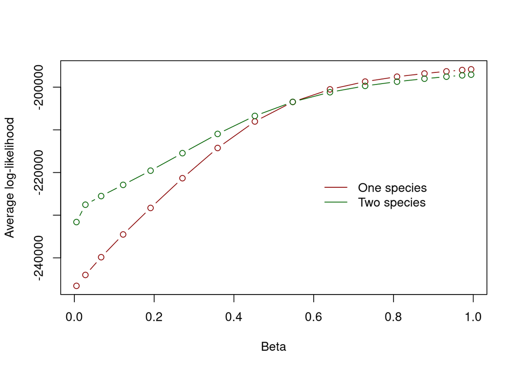

```r
plot(bw1$beta, bw1$ElnfX, type = 'b', col = 'darkred', xlab = 'Beta',
     ylab = 'Average log-likelihood')
lines(bw2$beta, bw2$ElnfX, type = 'b', col = 'darkgreen')
legend(0.6, -220000, c('One species', 'Two species'),
       lty = 1, col = c('darkred', 'darkgreen'), bty='n')
```

```r
MarginalLogLikelihood1
```

```
## [1] -211556.1
```

```r
MarginalLogLikelihood2
```

```
## [1] -208283.5
```

```r
BF
```

```
## [1] 3272.612
```

The estimated marginal log-likelihoods suggest a very strong support for the model with two species.